# Final analysis (2/2) — Effector CD4+ PCA, limma-voom DE/DAR, integration, vs paper Supp Data 3–4

**Paper methods mirrored here**

- **RNA:** **CPM > 10** in ≥ 2 Effector CD4+ libraries, then keep **`GENETYPE == "protein-coding"`** (annotation via `mapIds` **only on CPM-passing genes**, ~8k—not the full matrix). *Order note:* the paper states protein-coding first then CPM; swapping to **CPM then protein-coding** matches the atlas notebooks and keeps annotation cheap. **TMM**; **voom**; **limma** with **`duplicateCorrelation(block = donor)`**; **BH *q* < 0.01** and **|log2FC| > 1** for DEGs.
- **ATAC:** **CPM ≥ 1** in ≥ 2 samples on the **full** atlas, then Effector CD4+ columns; **TMM**; **voom**; **limma** with **TSS enrichment** covariate and **donor** via **`duplicateCorrelation`**; **BH < 0.01** and **|log2FC| > 1** for DARs.
- **Integration:** proximal DAR genes (ChIPseeker ±50 kb TSS) vs DEG symbols; Venn; scatter of log2FC.
- **Paper tables:** `Supplementary_data_3_ATAC_stimulation_DA_peaks.txt` and `Supplementary_data_4_RNA_stimulation_DE_genes.txt` (contrast `Effector_CD4pos_T_S-Effector_CD4pos_T_U`) for rank / logFC agreement.

**Runtime (same ballpark as `paper_aligned_atlas_filter/`):** run **`01_matrices_metadata.Rmd` first** (seconds). This notebook spends most time on **(1)** reading full ATAC + RNA counts, **(2)** **voom** on the atlas-filtered peak matrix, and **(3)** ChIPseeker. **Progress:** use **`rmarkdown::render(..., quiet = FALSE)`** from the shell (or **Knit** in RStudio) so you see **`i/n [chunk-name]`**; each heavy chunk starts with **`.run_step("02 — …")`** so the **HTML** also records what ran.

```r
library(limma)
library(edgeR)
library(ggplot2)
library(dplyr)
library(ggrepel)
library(readxl)
library(ChIPseeker)
library(TxDb.Hsapiens.UCSC.hg19.knownGene)
library(org.Hs.eg.db)
library(GenomicRanges)
library(VennDiagram)
txdb <- TxDb.Hsapiens.UCSC.hg19.knownGene
```

# 1 Paths

```r
.run_step("02 — paths and file checks")
```

```
##
## [23:00:20] 02 — paths and file checks
```

```r
path_atac <- file.path(repo_root, "data", "GSE118189_ATAC_counts.txt.gz")
path_rna_gz <- file.path(repo_root, "data", "GSE118165_raw_counts_GRCh38.p13_NCBI.tsv.gz")
path_rna_plain <- file.path(repo_root, "data", "GSE118165_raw_counts_GRCh38.p13_NCBI.tsv")
path_gsm_map <- file.path(repo_root, "data", "GSE118165_GSM_to_sample_id.tsv")
path_meta <- file.path(repo_root, "final_analysis", "sample_metadata.txt")
path_qc <- file.path(repo_root, "data", "Supplementary_tables.xlsx")
path_paper_atac <- file.path(repo_root, "Supplementary_data_3_ATAC_stimulation_DA_peaks.txt")
path_paper_rna <- file.path(repo_root, "Supplementary_data_4_RNA_stimulation_DE_genes.txt")
qc_sheet <- "ATAC-seq samle QC"
out_dir <- "results"
paper_contrast <- "Effector_CD4pos_T_S-Effector_CD4pos_T_U"
paper_rna_n_genes <- 13512L
paper_atac_n_peaks <- 671448L

path_rna <- if (file.exists(path_rna_gz)) path_rna_gz else path_rna_plain
rna_open <- if (grepl("\\.gz$", path_rna)) function() gzfile(path_rna, "rt") else function() file(path_rna, "rt")

stopifnot(
  file.exists(path_atac),
  file.exists(path_rna),
  file.exists(path_gsm_map),
  file.exists(path_meta),
  file.exists(path_qc),
  file.exists(path_paper_atac),
  file.exists(path_paper_rna)
)
```

```r
.run_step("02 — read metadata + TSS QC")
```

```
##
## [23:00:20] 02 — read metadata + TSS QC
```

```r
meta <- read.table(path_meta, header = TRUE, sep = "\t", row.names = 1, check.names = FALSE)
if ("in_atac" %in% colnames(meta)) meta$in_atac <- NULL
if ("in_rna" %in% colnames(meta)) meta$in_rna <- NULL

qc <- read_excel(path_qc, sheet = qc_sheet)
qc_tss <- qc %>%
  dplyr::distinct(.data$sample, .keep_all = TRUE) %>%
  dplyr::select(sample = .data$sample, tss_enrichment = .data$tss_enrichment)
```

# 2 Load full matrices

```r
.run_step("02 — load full ATAC matrix (I/O + parse; can take several minutes)")
```

```
##
## [23:00:20] 02 — load full ATAC matrix (I/O + parse; can take several minutes)
```

```r
atac_raw <- read.table(
  gzfile(path_atac),
  header = TRUE,
  sep = "\t",
  row.names = 1,
  check.names = FALSE
)
atac_full <- as.matrix(atac_raw)
storage.mode(atac_full) <- "double"
rm(atac_raw)
gc(verbose = FALSE)
```

```
##             used   (Mb) gc trigger   (Mb) limit (Mb)  max used   (Mb)
## Ncells  11237334  600.2   16499871  881.2         NA  12418066  663.2
## Vcells 168934041 1288.9  379102071 2892.4      49152 314211300 2397.3
```

```r
dim(atac_full)
```

```
## [1] 829942    175
```

```r
.run_step("02 — load full RNA counts + rename GSM → sample_id")
```

```
##
## [23:00:39] 02 — load full RNA counts + rename GSM → sample_id
```

```r
rna_raw <- read.table(
  rna_open(),
  header = TRUE,
  sep = "\t",
  row.names = 1,
  check.names = FALSE
)
rna_full <- as.matrix(rna_raw)
storage.mode(rna_full) <- "double"
gsm_map <- read.table(path_gsm_map, header = TRUE, sep = "\t", stringsAsFactors = FALSE)
stopifnot(all(colnames(rna_full) %in% gsm_map$GSM))
colnames(rna_full) <- gsm_map$sample_id[match(colnames(rna_full), gsm_map$GSM)]
rm(rna_raw)
gc(verbose = FALSE)
```

```
##             used   (Mb) gc trigger   (Mb) limit (Mb)  max used   (Mb)
## Ncells  11238115  600.2   16499871  881.2         NA  12418066  663.2
## Vcells 175453220 1338.7  379102071 2892.4      49152 314211300 2397.3
```

```r
dim(rna_full)
```

```
## [1] 39376   165
```

# 3 Effector CD4+ samples (both assays)

```r
.run_step("02 — subset to Effector CD4+ samples present in both assays")
```

```
##
## [23:00:40] 02 — subset to Effector CD4+ samples present in both assays
```

```r
in_both <- intersect(colnames(atac_full), colnames(rna_full))
keep_samples <- intersect(
  rownames(meta)[meta$cell_type == "Effector_CD4pos_T"],
  in_both
)
length(keep_samples)
```

```
## [1] 6
```

```r
meta_sub <- meta[keep_samples, , drop = FALSE]
meta_sub$donor <- factor(meta_sub$donor)
meta_sub$condition <- factor(meta_sub$condition, levels = c("resting", "stimulated"))

knitr::kable(
  as.data.frame.matrix(table(meta_sub$donor, meta_sub$condition)),
  caption = "Donor × condition (Effector CD4+)"
)
```

Donor × condition (Effector CD4+)

|  | resting | stimulated |
| --- | --- | --- |
| 1001 | 1 | 1 |
| 1002 | 0 | 1 |
| 1003 | 1 | 1 |
| 1004 | 1 | 0 |

```r
cd <- meta_sub %>%
  tibble::rownames_to_column("sample") %>%
  left_join(qc_tss, by = "sample") %>%
  tibble::column_to_rownames("sample")
stopifnot(!any(is.na(cd$tss_enrichment)))
cd$tss_z <- as.numeric(scale(cd$tss_enrichment))
```

# 4 ATAC: atlas-wide CPM, then CD4+ | RNA: CPM > 10 (CD4+), then protein-coding + `mapIds` only on retained genes

```r
.run_step("02 — ATAC atlas CPM filter + RNA CPM + protein-coding + mapIds (small sets)")
```

```
##
## [23:00:40] 02 — ATAC atlas CPM filter + RNA CPM + protein-coding + mapIds (small sets)
```

```r
dge_atac_full <- DGEList(counts = atac_full)
keep_atac_peaks <- rowSums(cpm(dge_atac_full) >= 1) >= 2L
atac_filtered <- atac_full[keep_atac_peaks, , drop = FALSE]
atac_sub <- atac_filtered[, keep_samples, drop = FALSE]

rna_cd4 <- rna_full[, keep_samples, drop = FALSE]
dge_rna_cell <- DGEList(counts = rna_cd4)
keep_rna_cpm <- rowSums(cpm(dge_rna_cell) > 10) >= 2L
rna_after_cpm <- rna_cd4[keep_rna_cpm, , drop = FALSE]

## `mapIds` on CPM-passing genes only (~8k), not the full count matrix.
gene_type <- mapIds(
  org.Hs.eg.db,
  keys = rownames(rna_after_cpm),
  column = "GENETYPE",
  keytype = "ENTREZID",
  multiVals = "first"
)
keep_pc <- !is.na(gene_type) & gene_type == "protein-coding"
rna_sub <- rna_after_cpm[keep_pc, , drop = FALSE]

entrez_ids <- rownames(rna_sub)
sym_rna <- mapIds(
  org.Hs.eg.db,
  keys = entrez_ids,
  column = "SYMBOL",
  keytype = "ENTREZID",
  multiVals = "first"
)
ens_rna <- mapIds(
  org.Hs.eg.db,
  keys = entrez_ids,
  column = "ENSEMBL",
  keytype = "ENTREZID",
  multiVals = "first"
)
gene_symbol_rna <- ifelse(is.na(sym_rna), entrez_ids, sym_rna)
names(gene_symbol_rna) <- entrez_ids
gene_ensembl_rna <- ifelse(is.na(ens_rna), NA_character_, ens_rna)
names(gene_ensembl_rna) <- entrez_ids

cat(
  "RNA genes after CPM>10 in ≥2 CD4+ libraries:", sum(keep_rna_cpm),
  "\n  …protein-coding subset:", nrow(rna_sub), "\n"
)
```

```
## RNA genes after CPM>10 in ≥2 CD4+ libraries: 8208
##   …protein-coding subset: 7644
```

```r
knitr::kable(data.frame(
  n_effector_libraries = length(keep_samples),
  n_atac_peaks_tested = nrow(atac_sub),
  paper_atac_peaks = paper_atac_n_peaks,
  n_rna_genes_tested = nrow(rna_sub),
  paper_rna_genes = paper_rna_n_genes
), caption = "Test set sizes vs paper (GEO matrices may differ).")
```

Test set sizes vs paper (GEO matrices may differ).

| n_effector_libraries | n_atac_peaks_tested | paper_atac_peaks | n_rna_genes_tested | paper_rna_genes |
| --- | --- | --- | --- | --- |
| 6 | 734428 | 671448 | 7644 | 13512 |

# 5 PCA — RNA (log-CPM, top 500 SD genes)

```r
.run_step("02 — PCA RNA")
```

```
##
## [23:00:42] 02 — PCA RNA
```

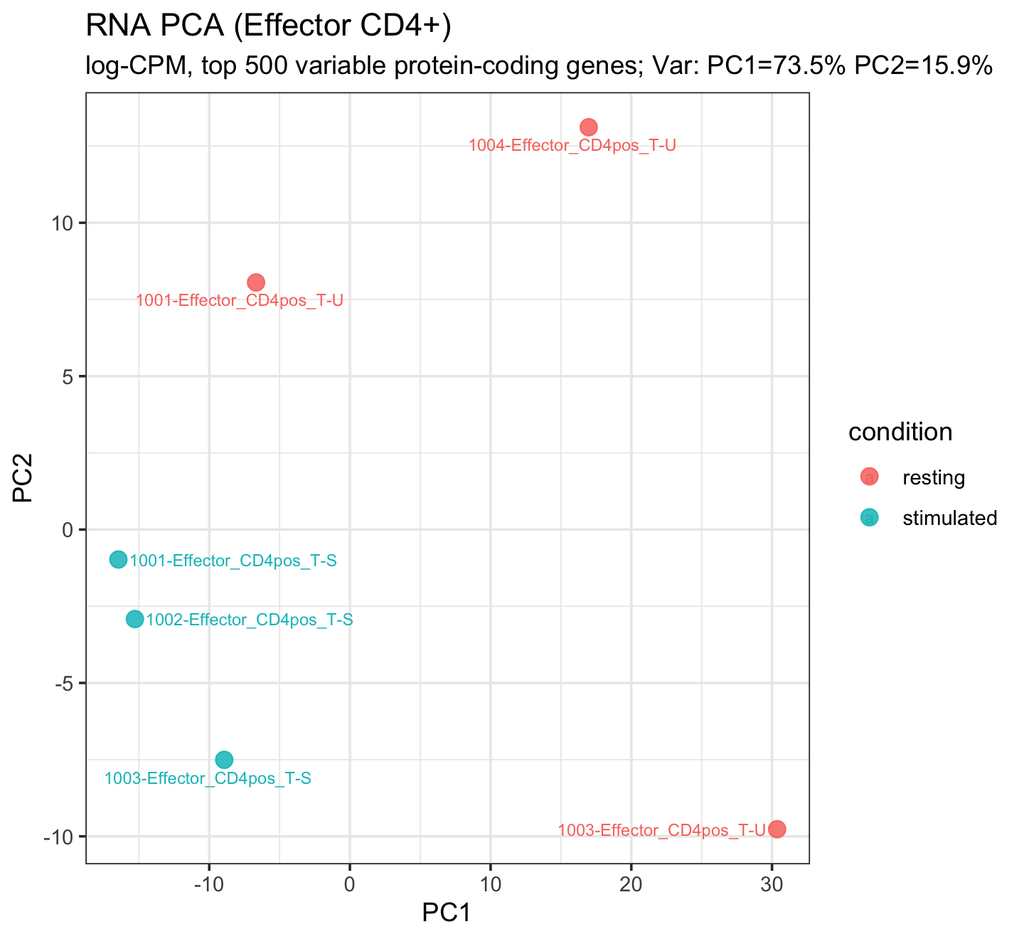

```r
dge_rna_pca <- DGEList(counts = rna_sub[, keep_samples, drop = FALSE])
dge_rna_pca <- calcNormFactors(dge_rna_pca, method = "TMM")
lcpm_rna <- cpm(dge_rna_pca, log = TRUE)
sdv <- apply(lcpm_rna, 1, stats::sd)
top_g <- order(sdv, decreasing = TRUE)[seq_len(min(500L, length(sdv)))]
X <- t(lcpm_rna[top_g, , drop = FALSE])
pc <- prcomp(X, center = TRUE, scale. = TRUE)
pv <- summary(pc)$importance[2, 1:2]
pc_df <- data.frame(
  sample = rownames(X),
  PC1 = pc$x[, 1],
  PC2 = pc$x[, 2],
  stringsAsFactors = FALSE
) %>%
  left_join(
    meta_sub %>% tibble::rownames_to_column("sample"),
    by = "sample"
  )

ggplot(pc_df, aes(.data$PC1, .data$PC2, color = .data$condition, label = .data$sample)) +
  geom_point(size = 3, alpha = 0.85) +
  ggrepel::geom_text_repel(size = 2.5, max.overlaps = 20) +
  labs(
    title = "RNA PCA (Effector CD4+)",
    subtitle = sprintf("log-CPM, top %d variable protein-coding genes; Var: PC1=%.1f%% PC2=%.1f%%", length(top_g), 100 * pv[1], 100 * pv[2]),
    x = "PC1",
    y = "PC2"
  ) +
  theme_bw()
```

```r
ggsave(file.path(out_dir, "pca_RNA_effector_CD4.pdf"), width = 6, height = 5.5)
```

# 6 PCA — ATAC (log-CPM, random 25k peaks for speed)

```r
.run_step("02 — PCA ATAC (25k random peaks)")
```

```
##
## [23:00:43] 02 — PCA ATAC (25k random peaks)
```

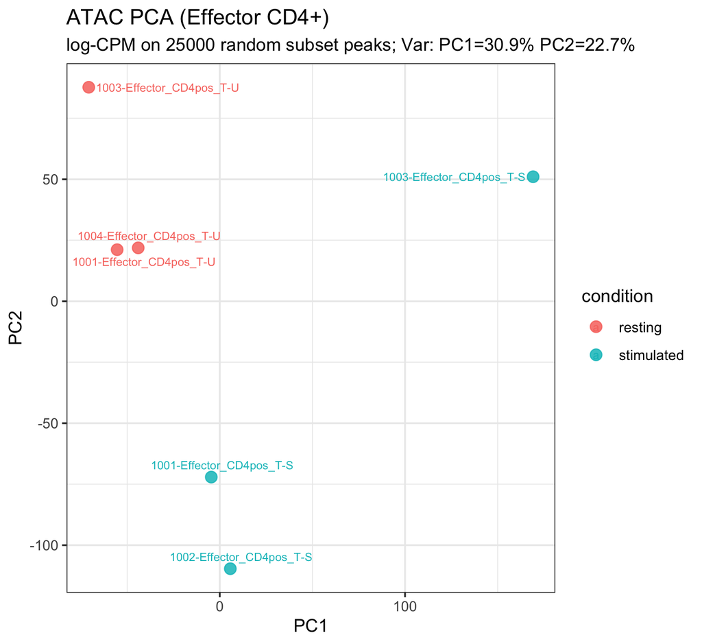

```r
set.seed(1)
dge_atac_pca <- DGEList(counts = atac_sub)
dge_atac_pca <- calcNormFactors(dge_atac_pca, method = "TMM")
lcpm_atac <- cpm(dge_atac_pca, log = TRUE)
nr <- nrow(lcpm_atac)
take <- sample.int(nr, min(25000L, nr))
Xa <- t(lcpm_atac[take, , drop = FALSE])
pca <- prcomp(Xa, center = TRUE, scale. = TRUE)
pva <- summary(pca)$importance[2, 1:2]
pca_df <- data.frame(
  sample = rownames(Xa),
  PC1 = pca$x[, 1],
  PC2 = pca$x[, 2],
  stringsAsFactors = FALSE
) %>%
  left_join(
    meta_sub %>% tibble::rownames_to_column("sample"),
    by = "sample"
  )

ggplot(pca_df, aes(.data$PC1, .data$PC2, color = .data$condition, label = .data$sample)) +
  geom_point(size = 3, alpha = 0.85) +
  ggrepel::geom_text_repel(size = 2.5, max.overlaps = 20) +
  labs(
    title = "ATAC PCA (Effector CD4+)",
    subtitle = sprintf("log-CPM on %d random subset peaks; Var: PC1=%.1f%% PC2=%.1f%%", length(take), 100 * pva[1], 100 * pva[2]),
    x = "PC1",
    y = "PC2"
  ) +
  theme_bw()
```

```r
ggsave(file.path(out_dir, "pca_ATAC_effector_CD4.pdf"), width = 6, height = 5.5)
```

# 7 limma — ATAC

```r
.run_step("02 — limma-voom ATAC (slow: large peak matrix)")
```

```
##
## [23:00:46] 02 — limma-voom ATAC (slow: large peak matrix)
```

```r
dge_atac <- DGEList(counts = atac_sub)
dge_atac <- calcNormFactors(dge_atac, method = "TMM")

design_atac <- model.matrix(~ tss_z + condition, data = cd)
v_atac <- voom(dge_atac, design_atac, plot = FALSE)
cor_atac <- duplicateCorrelation(v_atac, design_atac, block = cd$donor)
fit_atac <- lmFit(
  v_atac,
  design_atac,
  block = cd$donor,
  correlation = cor_atac$consensus
)
fit_atac <- eBayes(fit_atac)

tt_atac <- topTable(
  fit_atac,
  coef = "conditionstimulated",
  number = Inf,
  sort.by = "none",
  adjust.method = "BH"
)
tt_atac$peak_id <- rownames(tt_atac)

sig_atac <- tt_atac %>%
  filter(.data$adj.P.Val < 0.01, abs(.data$logFC) > 1)
cat("DARs q<0.01, |logFC|>1 — up:", sum(sig_atac$logFC > 0), " down:", sum(sig_atac$logFC < 0), "\n")
```

```
## DARs q<0.01, |logFC|>1 — up: 18707  down: 2047
```

```r
cor_atac$consensus
```

```
## [1] -0.2207337
```

# 8 limma — RNA

```r
.run_step("02 — limma-voom RNA")
```

```
##
## [23:07:30] 02 — limma-voom RNA
```

```r
dge_rna <- DGEList(counts = rna_sub)
dge_rna <- calcNormFactors(dge_rna, method = "TMM")

design_rna <- model.matrix(~ condition, data = cd)
v_rna <- voom(dge_rna, design_rna, plot = FALSE)
cor_rna <- duplicateCorrelation(v_rna, design_rna, block = cd$donor)
fit_rna <- lmFit(
  v_rna,
  design_rna,
  block = cd$donor,
  correlation = cor_rna$consensus
)
fit_rna <- eBayes(fit_rna)

tt_rna <- topTable(
  fit_rna,
  coef = "conditionstimulated",
  number = Inf,
  sort.by = "none",
  adjust.method = "BH"
)
tt_rna$gene_id <- rownames(tt_rna)
tt_rna$SYMBOL <- unname(gene_symbol_rna[tt_rna$gene_id])
tt_rna$ENSEMBL <- unname(gene_ensembl_rna[tt_rna$gene_id])

sig_rna <- tt_rna %>%
  filter(.data$adj.P.Val < 0.01, abs(.data$logFC) > 1)
cat("Genes in voom:", nrow(dge_rna), "\n")
```

```
## Genes in voom: 7644
```

```r
cat("DEGs q<0.01, |logFC|>1 — up:", sum(sig_rna$logFC > 0), " down:", sum(sig_rna$logFC < 0), "\n")
```

```
## DEGs q<0.01, |logFC|>1 — up: 170  down: 105
```

```r
cor_rna$consensus
```

```
## [1] 0.5571974
```

# 9 Volcano plots

```r
volcano_limma <- function(tt, id_col, label_map, title, outfile,
                          lfc_cut = 1, q_cut = 0.01,
                          sig_color = "#c0392b", ns_color = "grey82") {
  feat <- tt[[id_col]]
  lab_txt <- unname(label_map[feat])
  lab_txt[is.na(lab_txt)] <- feat[is.na(lab_txt)]

  df <- tt %>%
    mutate(
      neglog10q = pmin(-log10(.data$adj.P.Val), 50, na.rm = TRUE),
      sig = !is.na(.data$adj.P.Val) & .data$adj.P.Val < q_cut & abs(.data$logFC) > lfc_cut,
      lab_text = lab_txt,
      rank_score = -log10(.data$adj.P.Val) * abs(.data$logFC)
    )

  n_sig_up <- sum(df$sig & df$logFC > 0, na.rm = TRUE)
  n_sig_down <- sum(df$sig & df$logFC < 0, na.rm = TRUE)

  to_label <- bind_rows(
    df %>% filter(.data$sig, .data$logFC > 0) %>% arrange(desc(.data$rank_score)) %>% head(20),
    df %>% filter(.data$sig, .data$logFC < 0) %>% arrange(desc(.data$rank_score)) %>% head(20)
  ) %>%
    mutate(
      lab = ifelse(nchar(as.character(.data$lab_text)) > 40,
        paste0(substr(.data$lab_text, 1, 37), "..."),
        as.character(.data$lab_text)
      )
    )

  subt <- sprintf(
    "Sig. up: %d  |  Sig. down: %d  (q<%.2g, |logFC|>%.1f)",
    n_sig_up, n_sig_down, q_cut, lfc_cut
  )

  p <- ggplot(df, aes(logFC, neglog10q, color = sig)) +
    geom_point(alpha = 0.35, size = 0.85) +
    scale_color_manual(values = c("FALSE" = ns_color, "TRUE" = sig_color), guide = "none") +
    geom_vline(xintercept = c(-lfc_cut, lfc_cut), linetype = "dashed", color = "grey45") +
    geom_hline(yintercept = -log10(q_cut), linetype = "dashed", color = "grey45") +
    ggrepel::geom_text_repel(
      data = to_label,
      aes(label = .data$lab),
      color = "grey15",
      size = 2.8,
      max.overlaps = 100,
      min.segment.length = 0,
      box.padding = 0.35,
      inherit.aes = TRUE
    ) +
    labs(title = title, subtitle = subt, x = "log2 FC (stim / rest)", y = expression(-log[10] ~ "q")) +
    theme_bw(base_size = 11)

  ggsave(file.path(out_dir, outfile), p, width = 7.5, height = 6.5)
  p
}
```

```r
.run_step("02 — volcano ATAC")
```

```
##
## [23:07:35] 02 — volcano ATAC
```

```r
peak_lab <- tt_atac$peak_id
names(peak_lab) <- tt_atac$peak_id
volcano_limma(
  tt_atac, "peak_id", peak_lab,
  "ATAC volcano (Effector CD4+)",
  "volcano_ATAC_effector_CD4.pdf",
  sig_color = "#d62728"
)
```

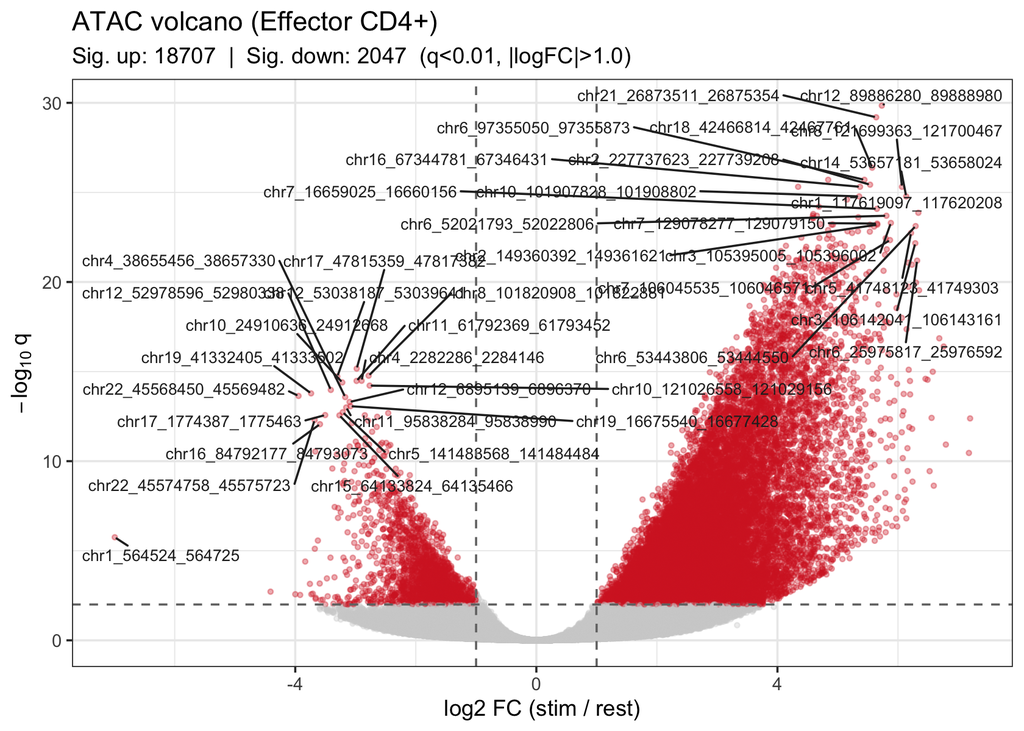

```r
.run_step("02 — volcano RNA")
```

```
##
## [23:07:59] 02 — volcano RNA
```

```r
volcano_limma(
  tt_rna, "gene_id", gene_symbol_rna,
  "RNA volcano (Effector CD4+, protein-coding, Entrez)",
  "volcano_RNA_effector_CD4.pdf",
  sig_color = "#1f77b4"
)
```

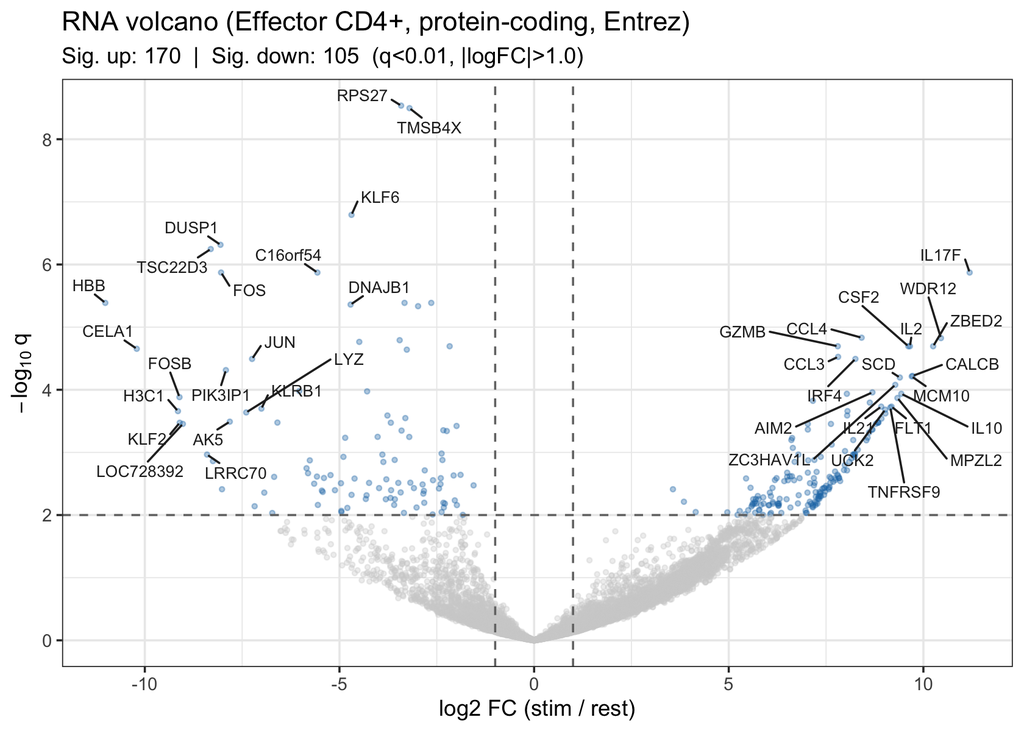

# 10 ChIPseeker overlap, Venn, scatter

```r
parse_peak_id_to_parts <- function(peak_ids) {
  t(vapply(peak_ids, FUN.VALUE = character(3), function(id) {
    p <- strsplit(id, "_", fixed = TRUE)[[1]]
    n <- length(p)
    if (n < 3) return(c(NA_character_, NA_character_, NA_character_))
    c(paste(p[seq_len(n - 2)], collapse = "_"), p[n - 1], p[n])
  }))
}
```

```r
.run_step("02 — ChIPseeker annotate DAR peaks (can take a while if many DARs)")
```

```
##
## [23:08:00] 02 — ChIPseeker annotate DAR peaks (can take a while if many DARs)
```

```r
DARs_df <- sig_atac
peak_coords <- parse_peak_id_to_parts(DARs_df$peak_id)
peak_start <- suppressWarnings(as.integer(peak_coords[, 2]))
peak_end <- suppressWarnings(as.integer(peak_coords[, 3]))
peak_ok <- !is.na(peak_coords[, 1]) & !is.na(peak_start) & !is.na(peak_end) & peak_end >= peak_start
DARs_df <- DARs_df[peak_ok, , drop = FALSE]
peak_coords <- peak_coords[peak_ok, , drop = FALSE]
peak_start <- peak_start[peak_ok]
peak_end <- peak_end[peak_ok]

DARs_gr <- GRanges(
  seqnames = peak_coords[, 1],
  ranges = IRanges(start = peak_start, end = peak_end),
  peak_id = DARs_df$peak_id,
  atac_lfc = DARs_df$logFC,
  atac_q = DARs_df$adj.P.Val
)

peak_anno <- annotatePeak(
  DARs_gr,
  tssRegion = c(-3000, 3000),
  TxDb = txdb,
  annoDb = "org.Hs.eg.db",
  assignGenomicAnnotation = TRUE
)
```

```
## >> preparing features information...      2026-05-13 23:08:01
## >> identifying nearest features...        2026-05-13 23:08:01
## >> calculating distance from peak to TSS...   2026-05-13 23:08:01
## >> assigning genomic annotation...        2026-05-13 23:08:01
## >> adding gene annotation...          2026-05-13 23:08:06
```

```
## >> assigning chromosome lengths           2026-05-13 23:08:06
## >> done...                    2026-05-13 23:08:06
```

```r
.run_step("02 — overlap proximal DAR genes with DEGs")
```

```
##
## [23:08:06] 02 — overlap proximal DAR genes with DEGs
```

```r
peak_anno_df <- as.data.frame(peak_anno)
proximal <- peak_anno_df %>% filter(abs(.data$distanceToTSS) <= 50000)

DAR_genes <- proximal %>%
  dplyr::select(peak_id = .data$peak_id, SYMBOL = .data$SYMBOL, atac_lfc = .data$atac_lfc, atac_q = .data$atac_q) %>%
  filter(!is.na(.data$SYMBOL)) %>%
  group_by(.data$SYMBOL) %>%
  slice_max(abs(.data$atac_lfc), n = 1) %>%
  ungroup()

DEGs_symbols <- sig_rna %>%
  transmute(SYMBOL = .data$SYMBOL, rna_lfc = .data$logFC, rna_q = .data$adj.P.Val) %>%
  filter(!is.na(.data$SYMBOL))

overlap <- inner_join(DAR_genes, DEGs_symbols, by = "SYMBOL") %>%
  mutate(
    direction = case_when(
      atac_lfc > 0 & rna_lfc > 0 ~ "open & up",
      atac_lfc < 0 & rna_lfc < 0 ~ "closed & down",
      atac_lfc > 0 & rna_lfc < 0 ~ "open & down",
      atac_lfc < 0 & rna_lfc > 0 ~ "closed & up",
      TRUE ~ NA_character_
    )
  )

knitr::kable(as.data.frame(table(overlap$direction)))
```

| Var1 | Freq |
| --- | --- |
| closed & down | 13 |
| closed & up | 2 |
| open & down | 36 |
| open & up | 78 |

```r
.run_step("02 — Venn diagram")
```

```
##
## [23:08:07] 02 — Venn diagram
```

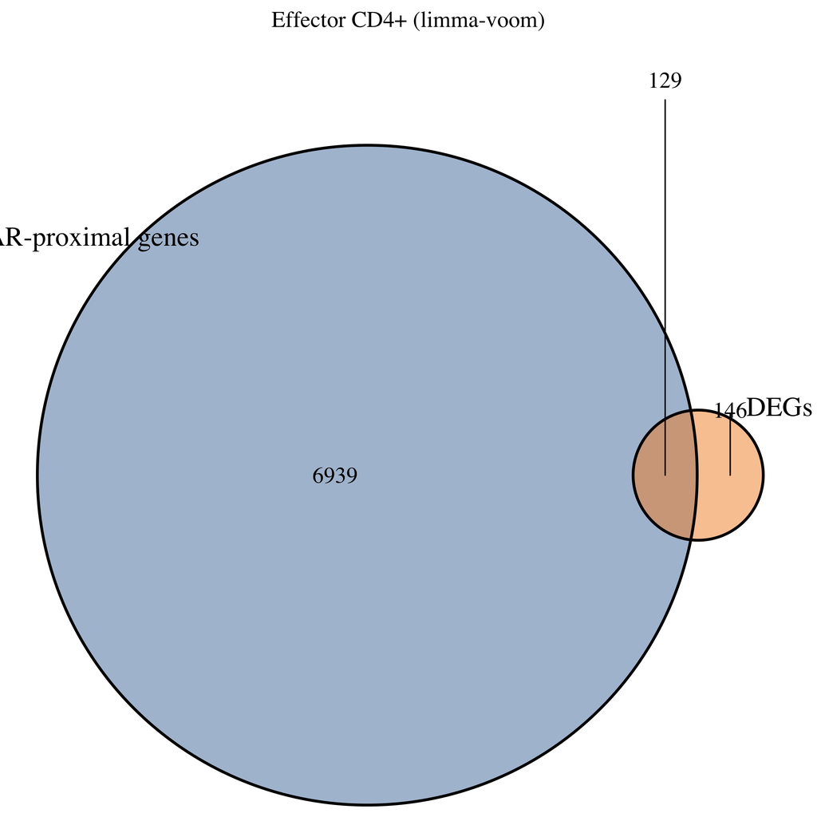

```r
invisible(utils::capture.output(
  venn.diagram(
    x = list(
      "DAR-proximal genes" = unique(DAR_genes$SYMBOL),
      "DEGs" = unique(DEGs_symbols$SYMBOL)
    ),
    filename = file.path(out_dir, "venn_DAR_DEG_effector_CD4.png"),
    imagetype = "png",
    fill = c("#4e79a7", "#f28e2b"),
    alpha = 0.5,
    cat.cex = 1.2,
    main = "Effector CD4+ (limma-voom)"
  )
))
knitr::include_graphics(file.path(out_dir, "venn_DAR_DEG_effector_CD4.png"))
```

```r
.run_step("02 — integration scatter")
```

```
##
## [23:08:07] 02 — integration scatter
```

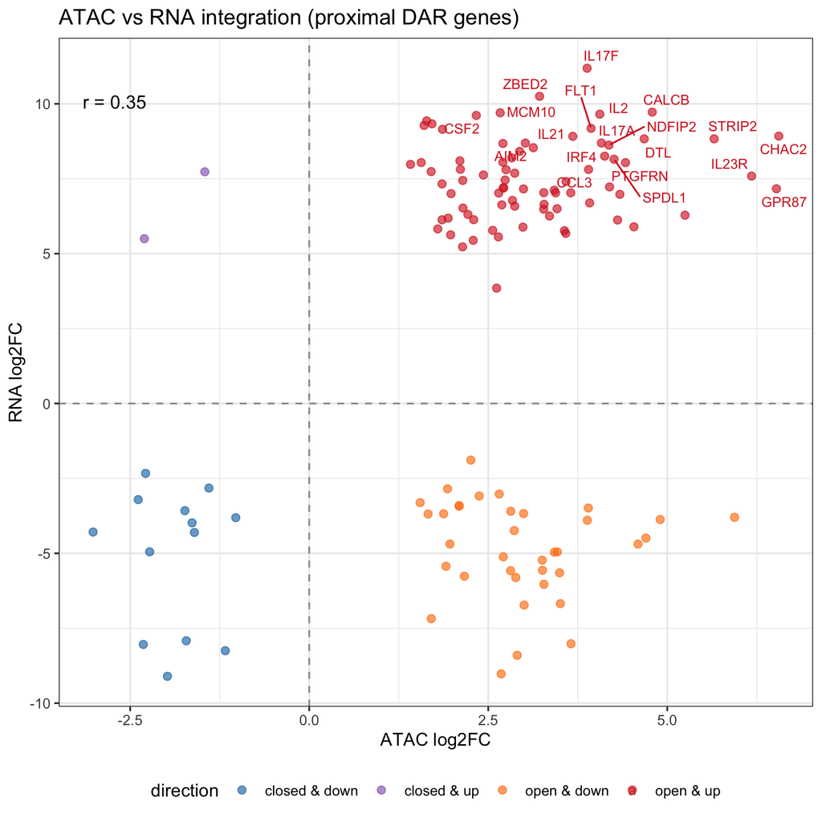

```r
direction_colors <- c(
  "open & up" = "#d62728",
  "closed & down" = "#1f77b4",
  "open & down" = "#ff7f0e",
  "closed & up" = "#9467bd"
)

if (nrow(overlap) > 1L) {
  p_scatter <- ggplot(overlap, aes(atac_lfc, rna_lfc, color = direction, label = SYMBOL)) +
    geom_hline(yintercept = 0, linetype = "dashed", color = "grey60") +
    geom_vline(xintercept = 0, linetype = "dashed", color = "grey60") +
    geom_point(alpha = 0.65, size = 2) +
    ggrepel::geom_text_repel(
      data = overlap %>%
        mutate(combined = abs(.data$atac_lfc) + abs(.data$rna_lfc)) %>%
        slice_max(.data$combined, n = 20),
      size = 3,
      max.overlaps = 20
    ) +
    scale_color_manual(values = direction_colors) +
    annotate(
      "text",
      x = min(overlap$atac_lfc, na.rm = TRUE) * 0.9,
      y = max(overlap$rna_lfc, na.rm = TRUE) * 0.9,
      label = paste0("r = ", round(cor(overlap$atac_lfc, overlap$rna_lfc), 2)),
      size = 4
    ) +
    labs(
      title = "ATAC vs RNA integration (proximal DAR genes)",
      x = "ATAC log2FC",
      y = "RNA log2FC"
    ) +
    theme_bw() +
    theme(legend.position = "bottom")
  print(p_scatter)
  ggsave(file.path(out_dir, "scatter_ATAC_RNA_effector_CD4.pdf"), p_scatter, width = 7, height = 7)
} else {
  knitr::asis_output("_Too few overlapping genes._")
}
```

# 11 Paper Supplementary Data 3 & 4 — ranks vs replication

```r
.run_step("02 — read paper supplementary DE/DA tables")
```

```
##
## [23:08:07] 02 — read paper supplementary DE/DA tables
```

```r
paper_atac <- read.table(path_paper_atac, header = TRUE, sep = "\t", stringsAsFactors = FALSE)
paper_rna <- read.table(path_paper_rna, header = TRUE, sep = "\t", stringsAsFactors = FALSE)
if ("peak_id" %in% names(paper_rna) && !"gene_id" %in% names(paper_rna)) {
  names(paper_rna)[names(paper_rna) == "peak_id"] <- "gene_id"
}

paper_atac_cd4 <- paper_atac %>% filter(.data$contrast == paper_contrast)
paper_rna_cd4 <- paper_rna %>% filter(.data$contrast == paper_contrast)

paper_atac_cd4 <- paper_atac_cd4 %>%
  mutate(
    rank_score_paper = -log10(.data$adj.P.Val) * abs(.data$logFC),
    paper_rank_atac = rank(-.data$rank_score_paper, ties.method = "min")
  )

paper_rna_cd4 <- paper_rna_cd4 %>%
  mutate(
    rank_score_paper = -log10(.data$adj.P.Val) * abs(.data$logFC),
    paper_rank_rna = rank(-.data$rank_score_paper, ties.method = "min")
  )

cat("Paper rows Effector CD4+ — ATAC:", nrow(paper_atac_cd4), " RNA:", nrow(paper_rna_cd4), "\n")
```

```
## Paper rows Effector CD4+ — ATAC: 22852  RNA: 866
```

```r
.run_step("02 — compare ATAC logFC to paper (joined peaks)")
```

```
##
## [23:08:09] 02 — compare ATAC logFC to paper (joined peaks)
```

```r
cmp_atac <- tt_atac %>%
  mutate(
    ours_rank = rank(-(-log10(.data$adj.P.Val) * abs(.data$logFC)), ties.method = "min")
  ) %>%
  inner_join(
    paper_atac_cd4 %>% dplyr::select(peak_id = .data$peak_id, logFC_paper = .data$logFC, adj.P.Val_paper = .data$adj.P.Val, paper_rank_atac),
    by = "peak_id"
  )

if (nrow(cmp_atac) > 10) {
  ca <- cor(cmp_atac$logFC, cmp_atac$logFC_paper, use = "complete.obs")
  cat("Pearson r (log2FC ours vs paper), ATAC peaks in both tables:", round(ca, 3), "\n")
}
```

```
## Pearson r (log2FC ours vs paper), ATAC peaks in both tables: 0.988
```

```r
sig_ids <- sig_atac$peak_id
top_compare_atac <- cmp_atac %>%
  filter(.data$peak_id %in% sig_ids) %>%
  arrange(.data$ours_rank) %>%
  dplyr::select(peak_id, logFC, adj.P.Val, ours_rank, logFC_paper, adj.P.Val_paper, paper_rank_atac) %>%
  head(25)
knitr::kable(top_compare_atac, caption = "Top 25 significant DARs here — paper ranks (Supp. Data 3)")
```

Top 25 significant DARs here — paper ranks (Supp. Data 3)

[output not shown]

```r
.run_step("02 — compare RNA logFC to paper (ENSEMBL join)")
```

```
##
## [23:08:09] 02 — compare RNA logFC to paper (ENSEMBL join)
```

```r
cmp_rna <- tt_rna %>%
  filter(!is.na(.data$ENSEMBL)) %>%
  mutate(
    ours_rank = rank(-(-log10(.data$adj.P.Val) * abs(.data$logFC)), ties.method = "min")
  ) %>%
  inner_join(
    paper_rna_cd4 %>%
      transmute(
        ENSEMBL = as.character(.data$gene_id),
        logFC_paper = .data$logFC,
        adj.P.Val_paper = .data$adj.P.Val,
        paper_rank_rna
      ),
    by = "ENSEMBL"
  )

if (nrow(cmp_rna) > 10) {
  cr <- cor(cmp_rna$logFC, cmp_rna$logFC_paper, use = "complete.obs")
  cat("Pearson r (log2FC ours vs paper), RNA genes (ENSEMBL match):", round(cr, 3), "\n")
}
```

```
## Pearson r (log2FC ours vs paper), RNA genes (ENSEMBL match): 0.974
```

```r
sig_ens <- sig_rna$ENSEMBL[!is.na(sig_rna$ENSEMBL)]
top_compare_rna <- cmp_rna %>%
  filter(.data$ENSEMBL %in% sig_ens) %>%
  arrange(.data$ours_rank) %>%
  dplyr::select(ENSEMBL, SYMBOL, logFC, adj.P.Val, ours_rank, logFC_paper, adj.P.Val_paper, paper_rank_rna) %>%
  head(25)
knitr::kable(top_compare_rna, caption = "Top 25 significant DEGs here — paper ranks (Supp. Data 4)")
```

Top 25 significant DEGs here — paper ranks (Supp. Data 4)

| ENSEMBL | SYMBOL | logFC | adj.P.Val | ours_rank | logFC_paper | adj.P.Val_paper | paper_rank_rna |
| --- | --- | --- | --- | --- | --- | --- | --- |
| ENSG00000112116 | IL17F | 11.188190 | 0.0000013 | 1 | 10.686411 | 0.0000001 | 7 |
| ENSG00000244734 | HBB | -11.015696 | 0.0000041 | 2 | -9.713715 | 0.0012233 | 97 |
| ENSG00000157514 | TSC22D3 | -8.306798 | 0.0000006 | 3 | -8.334919 | 0.0000000 | 5 |
| ENSG00000120129 | DUSP1 | -8.056686 | 0.0000005 | 4 | -7.367276 | 0.0000000 | 16 |
| ENSG00000138442 | WDR12 | 10.451129 | 0.0000150 | 5 | 7.962818 | 0.0000029 | 33 |
| ENSG00000177494 | ZBED2 | 10.251064 | 0.0000202 | 6 | 10.569524 | 0.0000000 | 1 |
| ENSG00000139610 | CELA1 | -10.207224 | 0.0000222 | 7 | -10.647308 | 0.0000001 | 8 |
| ENSG00000170345 | FOS | -8.040772 | 0.0000013 | 8 | -7.207692 | 0.0000001 | 20 |
| ENSG00000109471 | IL2 | 9.653838 | 0.0000202 | 9 | 10.327633 | 0.0000000 | 2 |
| ENSG00000164400 | CSF2 | 9.612888 | 0.0000202 | 10 | 10.994427 | 0.0000000 | 3 |
| ENSG00000175868 | CALCB | 9.722723 | 0.0000601 | 11 | 7.953167 | 0.0000005 | 22 |
| ENSG00000065328 | MCM10 | 9.700803 | 0.0000612 | 12 | 6.693898 | 0.0000596 | 98 |
| ENSG00000099194 | SCD | 9.394625 | 0.0000637 | 14 | 9.166736 | 0.0000001 | 10 |
| ENSG00000136634 | IL10 | 9.432481 | 0.0001160 | 16 | 7.514608 | 0.0000006 | 26 |
| ENSG00000137265 | IRF4 | 8.253405 | 0.0000322 | 17 | 7.368296 | 0.0000001 | 18 |
| ENSG00000100453 | GZMB | 7.800448 | 0.0000202 | 18 | 8.221466 | 0.0009597 | 132 |
| ENSG00000149573 | MPZL2 | 9.333581 | 0.0001352 | 19 | 8.271733 | 0.0000062 | 34 |
| ENSG00000125740 | FOSB | -9.109753 | 0.0001312 | 20 | -6.726469 | 0.0002914 | 141 |
| ENSG00000163568 | AIM2 | 8.690331 | 0.0001101 | 22 | 6.909043 | 0.0000001 | 25 |
| ENSG00000100100 | PIK3IP1 | -7.917482 | 0.0000486 | 24 | -5.818855 | 0.0000791 | 140 |
| ENSG00000049249 | TNFRSF9 | 9.150097 | 0.0001919 | 25 | 8.310858 | 0.0002147 | 81 |
| ENSG00000138684 | IL21 | 8.915489 | 0.0001858 | 27 | 9.006762 | 0.0000000 | 4 |
| ENSG00000143179 | UCK2 | 9.018788 | 0.0002078 | 28 | 8.489431 | 0.0000001 | 12 |
| ENSG00000102471 | NDFIP2 | 8.623254 | 0.0001603 | 29 | 8.025801 | 0.0000000 | 9 |
| ENSG00000185905 | C16orf54 | -5.566438 | 0.0000013 | 31 | -4.621908 | 0.0000000 | 62 |

```r
cat(
  "\nNote: genes without 1:1 ENSEMBL mapping from Entrez are excluded from RNA join.",
  "\nATAC join requires identical peak_id strings between GEO counts and paper table.\n"
)
```

```
##
## Note: genes without 1:1 ENSEMBL mapping from Entrez are excluded from RNA join.
## ATAC join requires identical peak_id strings between GEO counts and paper table.
```

# 12 Summary

```r
.run_step("02 — summary")
```

```
##
## [23:08:09] 02 — summary
```

```r
cat(
  "ATAC peaks tested:", nrow(atac_sub),
  "\nDARs q<0.01 |logFC|>1:", nrow(sig_atac),
  "\nRNA genes tested:", nrow(rna_sub),
  "\nDEGs q<0.01 |logFC|>1:", nrow(sig_rna),
  "\nOverlap genes (proximal):", nrow(overlap),
  "\nResults:", normalizePath(out_dir), "\n"
)
```

```
## ATAC peaks tested: 734428
## DARs q<0.01 |logFC|>1: 20754
## RNA genes tested: 7644
## DEGs q<0.01 |logFC|>1: 275
## Overlap genes (proximal): 129
## Results: /Users/emrunali/atac_rna_seq/final_analysis/results
```

```r
.run_step("02 — sessionInfo()")
```

```
##
## [23:08:09] 02 — sessionInfo()
```